REVIEW ARTICLE

Bone marrow concentrate injections for the treatment

of osteoarthritis: evidence from preclinical findings to the clinical

application

Carola Cavallo<sup>1</sup>& Angelo Boffa<sup>2,3</sup>

& Luca Andriolo<sup>2</sup>& Simone Silva<sup>2,3</sup>& Brunella Grigolo<sup>1</sup>& Stefano Zaffagnini<sup>2,3</sup>&

Giuseppe Filardo<sup>4</sup>

Received: 30 April 2020 /Accepted: 3 July 2020

# The Author(s) 2020

Abstract

Purpose To investigate the available literature on the use of bone marrow aspirate concentrate (BMAC) and summarize the

current evidence supporting its potential for the injective treatment of joints affected by osteoarthritis (OA).

Methods A systematic literature search was conducted on three electronic databases (PubMed, Embase, and Cochrane Library)

in April 2020, using the following string: “((bone marrow concentrate) OR (BMC) OR (bone marrow aspirate concentrate) OR

(BMAC)) AND (osteoarthritis)”, and inclusion criteria: clinical and preclinical (animal) studies of any level of evidence, written

in English language, and evaluating the intra-articular or subchondral use of BMAC for the injective treatment of OA joints.

Results The publication trend remarkably increased over time. A total of 22 studies were included in the qualitative data synthesis:

four preclinical studies and 18 clinical studies, for a total number of 4626 patients. Safety was documented by all studies, with a low

number of adverse events. An overall improvement in pain and function was documented in most of the studies, but the clinical

studies present significant heterogeneity, few patients, short-term follow-up, and overall poor methodology.

Conclusion There is a growing interest in the field of BMAC injections for the treatment of OA, with promising results in

preclinical and clinical studies in terms of safety and effectiveness. Nevertheless, the current knowledge is still preliminary.

Preclinical research is still needed to optimize BMAC use, as well as high-level large controlled trials to better understand the real

potential of BMAC injections for the treatment of patients affected by OA.

Keywords Bone marrow concentrate <sup>.</sup>BMAC <sup>.</sup>Injective <sup>.</sup>Intra-articular <sup>.</sup>Osteoarthritis <sup>.</sup>Cartilage

Introduction

Osteoarthritis (OA) is a degenerative disease characterized by

progressive deterioration and loss of articular cartilage with con-

comitant structural and functional changes in the entire joint [1].

Its incidence and prevalence are rising, in particular among older

adults in developed countries, likely related to the aging of the

population and increasing obesity [2–4]. Clinical features of OA

are mostly characterized by signs and symptoms of inflammation,

including pain, effusions, stiffness, and loss of mobility, often

associated with significant functional impairment [5]. Current

management strategies include weight loss, physical treatments,

oral medications, such as non-steroidal anti-inflammatory drugs

and acetaminophen, and intra-articular injection therapies with

corticosteroids and hyaluronic acid (HA) [6]. Nevertheless, these

treatment options mainly provide symptom relief rather than

disease-modifying changes to the intra-articular environment [7].

The use of orthobiologics is gaining increasing interest due

to the availability of new promising products to address OA.

Among these, platelet concentrates are now considered a suit-

able option to treat OA, with results going beyond the mere

placebo effects expected for injective treatments and higher

than those provided by other traditional products, although

* Angelo Boffa

angeloboffa@libero.it

1

Laboratorio RAMSES, IRCCS Istituto Ortopedico Rizzoli, Via di

Barbiano, 1/10, 40136 Bologna, Italy

2

Clinica Ortopedica e Traumatologica II, IRCCS Istituto Ortopedico

Rizzoli, Via Pupilli, 1, 40136 Bologna, Italy

3

Alma Mater Studiorum - Università di Bologna, Via Zamboni, 33,

40126 Bologna, Italy

4

Applied and Translational Research (ATR) Center, IRCCS Istituto

Ortopedico Rizzoli, Via di Barbiano, 1/10, Bologna, Italy

https://doi.org/10.1007/s00264-020-04703-w

/ Published online: 13 July 2020

International Orthopaedics (2021) 45:525–538

with still suboptimal outcomes [8, 9]. More recently, mesen-

chymal stromal cells (MSCs) have been proposed as a prom-

ising alternative for OA treatment thanks to their structural

contribution to tissue repair and even more their immunomod-

ulatory and anti-inflammatory actions, through direct cell-to-

cell interaction or secretion of bioactive factors [10, 11].

MSCs can be easily isolated from various tissues, such as

bone marrow, adipose tissue, synovial membrane, peripheral

blood, and skin [12]. Bone marrow MSCs (BMSCs) were the

first type of MSCs to be identified and, due to the ease of

collection, bone marrow currently represents a commonly

used source of MSCs [13]. In particular, this type of MSCs

has been either applied as a cell suspension after being ex-

panded by culture or used as a simple bone marrow concen-

trate (BMC), thanks to their relative abundance [14].

Considering the strict regulations and the problems related to

cell manipulation and expansion, cultured BMSCs have been

widely explored in the preclinical setting, but their use is ex-

tremely limited in clinical practice, both in Europe and in the

USA [15–19]. Conversely, the minimal cell manipulation ap-

proach, allowing to obtain a bone marrow aspirate concentrate

(BMAC) directly on site in a one-step treatment, has been

widely utilized in the clinical practice for the treatment of

cartilage lesions first and, more recently, has been proposed

as a promising injective approach to treat degenerative ortho-

paedic conditions [20, 21]. Nevertheless, the real potential of

BMAC as intra-articular OA treatment remains controversial

[22].

The aim of this systematic review was to examine the avail-

able literature on the use of BMAC, evaluating preclinical and

clinical studies, in order to summarize the current evidence

supporting its potential for the injective treatment of joints affect-

ed by OA. The hypothesis of the current study was that the

available preclinical studies support the rationale for the injective

use of BMAC, and that an increasing number of clinical studies

reports safety and effectiveness of this biological approach.

Material and methods

A systematic review of the literature was performed on the use

of BMAC as injective treatment for joints affected by OA. A

literature search was conducted on three electronic databases

(PubMed, Embase, and Cochrane Library) on April 20th,

2020, with no time limitation and without any filters, using

the following string: “((bone marrow concentrate) OR (BMC)

OR (bone marrow aspirate concentrate) OR (BMAC)) AND

(osteoarthritis)”. According to the Preferred Reporting Items

for Systematic Reviews and Meta-Analysis (PRISMA) and

Cochrane guidelines [23], the article selection and data extrac-

tion process were conducted separately by two authors (AB

and SS). The initial title and abstract screenings were made

using the following inclusion criteria: clinical and preclinical

(animal) studies of any level of evidence, written in English

language, and evaluating the intra-articular or subchondral use

of BMAC for the injective treatment of joints with OA.

Exclusion criteria consisted of articles written in other lan-

guages, literature reviews, basic science in vitro articles, case

reports, congress abstracts, studies on joint diseases different

from OA, studies on other BMAC applications (e.g., use as

augmentation to other surgical techniques), and studies deal-

ing only with expanded or otherwise manipulated MSCs. In

the second step, the full texts of the selected articles were

screened, with further exclusion according to the previously

described criteria. Additionally, all references from the select-

ed papers and previously published relevant reviews were also

screened. Two investigators independently reviewed each ar-

ticle (AB and SS), and any discrepancies between them were

resolved by discussion and consensus. For the included stud-

ies, relevant data were extracted from article texts, tables, and

figures, and then summarized and analyzed according to the

purpose of the present work. In particular, the following data

were collected for preclinical studies: year of publication, an-

imals evaluated, joint involved, OA model, types of treatment,

BMAC harvest site and characteristics, follow-up length, eval-

uation methods, and results. For clinical studies, the following

data were collected: year of publication, study design, joint

involved, treatment type and schedule, BMAC manufacturing

and characteristics, number of evaluated subjects, subject’s

characteristics, follow-up length, main results, and adverse

events.

The effectiveness of BMAC injective therapy was evaluat-

ed by summarizing the reported benefits, while the safety of

the procedures was evaluated identifying the reported side

effects. To assess the methodological quality of the included

clinical studies, the subscales of a Coleman Methodology

Score, modified by Kon et al. [24], were determined for each

study by two separate authors (AB and SS). In case of dis-

agreement between the two authors, divergences were

discussed and a consensus was reached.

Results

The flowchart of the article selection process is reported in

Fig. 1. After duplicates were removed, the initial search iden-

tified 2027 records, whose abstracts were screened and select-

ed according to the inclusion/exclusion criteria. Four articles

were identified through the reference lists, which gave a total

of 29 articles assessed for eligibility. However, five studies

were excluded being congress abstracts, one study was ex-

cluded because it was a case report [25], and one study was

excluded because it provided the same data of another includ-

ed study [26]. Thus, a total of 22 studies were included in the

qualitative data synthesis: 4 preclinical studies [27–30] and 18

clinical studies [31–48]. Since the first reports in 2014, the

526

International Orthopaedics (SICOT) (2021) 45:525–538

publication trend remarkably increased over time, especially

for the clinical studies, with over 50% of the articles published

from 2018 (Fig. 2).

Preclinical studies

The potential of BMAC for the injective OA treatment has been

tested in 4 animal studies (Table 1). All of them were compar-

ative studies investigating the results of BMAC in knee OA

models against placebo (saline), HA, platelet-rich plasma

(PRP), and cultured BMSCs. Knee OA was induced by anterior

cruciate ligament transection in all four studies, also associated

with meniscectomy in two studies. Bone marrow was harvested

from the iliac crest in three studies and from the proximal tibia

in one study. The used animals included rabbit (two studies),

sheep, and goat (one study each), which were sacrificed from

six to 20 weeks after the intra-articular injections, and then

evaluated through macroscopic and radiologic evaluation, his-

tological examination, and immunohistochemical analysis.

The macroscopic evaluation of articular cartilage was de-

scribed in three studies, all showing better results in animals

treated with BMAC compared with control groups. Song et al.

[29] and Singh et al. [30] reported less severe cartilage dete-

rioration compared with saline. In addition, beside showing

the benefits vs. saline, Wang et al. [28] documented in the

BMAC group only focal and superficial cartilage erosion

and mild osteophyte development with respect to the PRP

group, where obvious extensive and full-thickness cartilage

defects combined with marked osteophyte development were

reported. Singh et al. [30] performed also a radiological eval-

uation, confirming the positive results by showing less severe

signs of OA (including osteophyte formation, subchondral

bone sclerosis, and articular surface irregularity) when isolat-

ed non-cultured BMSCs were injected compared with saline.

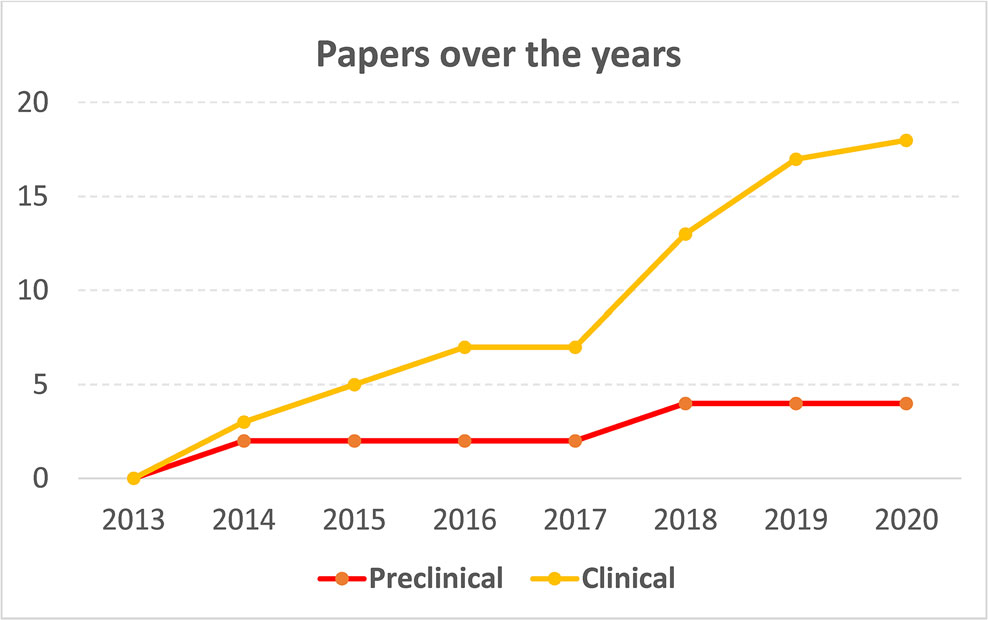

Fig. 2 Cumulative number of preclinical and clinical studies on BMAC

injective OA treatment

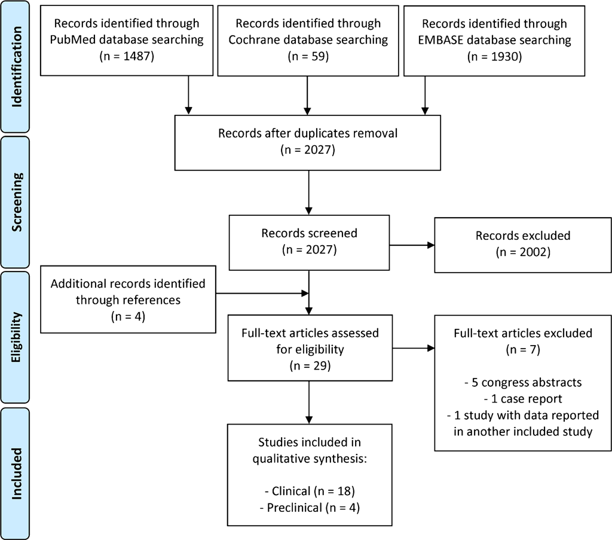

Fig. 1 Flowchart showing the

systematic review selection

process

527

International Orthopaedics (SICOT) (2021) 45:525–538

Table 1

Preclinical studies

Author and

year

Animal and OA

model

Joint

Treatment

Harvest site

BMAC characteristics

Follow-up and evaluation

Results

Desando G

et al. 2018

[27]

Rabbit (48 knees)

OA induced by

ACL

transection

Knee

12 BMAC vs. 12 cultured

BMSCs vs. 12 BMAC +

HA vs.

12 cultured BMMCs + HA

Single IA injection

Iliac crest

Centrifugation

procedure

at 400g

for 10 min at 20 °C

2 × 106 cells/ml

8 weeks

Cell biodistribution,

histologic,

immunohistochemical,

and synovial fluid

analysis

BMAC showed effectiveness for the injective

OA treatment, with similar results than

BMSCs and better results for the

association of BMAC + HA.

Wang Z et al.

2018 [28]

Goat (24 knees)

OA induced by

ACL

transection and

meniscectomy

Knee

6 BMAC vs. 6 saline

vs. 6 PRP

Three IA injections

(once every 4 weeks)

Iliac crest

Two-step centrifugation

procedure

5 ml with 1190.3 × 106

cells/ml

6 weeks

Macroscopic, histologic,

immunohistochemical,

and synovial fluid

analysis

Higher cartilage protection in the BMAC

group than both PRP and saline groups.

Song F et al.

2014 [29]

Sheep (18 knees)

OA induced by

ACL

transection and

meniscectomy

Knee

6 BMSCs vs. 6 saline

vs. 6 cultured MSCs

Single IA injection

Iliac crest

BMSCs were isolated by

density gradient

centrifugation, and were

resuspended in PBS

5 ml with 0.9 × 106

cells/ml

8 weeks

Macroscopic,

histopathologic, ELISA

and proteoglycan assay,

RT-PCR analysis of

cartilage

BMSCs and cultured MSCs provided both

good results in terms of macroscopic and

histologic findings, GAG protection,

cytokines, and cartilage biomarkers

changes.

Singh A et al.

2014 [30]

Rabbit (20 knees)

OA induced by

ACL

transection

Knee

10 BMSCs vs. 10

saline

Single IA injection

Proximal tibia

BMSCs were isolated by

density gradient

following Pittenger’s

method

1 ml with 1 × 106 cells/ml

20 weeks

Macroscopic, radiologic,

and histopathologic

analysis

BMSCs provided significant

histopathological and radiological

improvement compared with control

group.

ACL anterior cruciate ligament; BMAC bone marrow aspirate concentrate; BMSCs bone marrow mesenchymal stromal cells; ELISA enzyme-linked immunosorbent assay; HA hyaluronic acid; IA intra-

articular; MSCs mesenchymal stromal cells; PBS phosphate-buffered saline; PRP platelet-rich plasma; RT-PCR real-time polymerase chain reaction

528

International Orthopaedics (SICOT) (2021) 45:525–538

The histological analysis was performed in all studies,

reporting better results in the BMAC group, with degenerative

changes and articular cartilage erosion limited within the su-

perficial layer, normal chondrocyte density, and abundant ex-

tracellular matrix preserved in the lower layers. Interestingly

Desando et al. [27] in a rabbit model demonstrated similar

results with respect to the use of cultured BMSCs and better

histological findings in joints treated with the combination of

BMAC and HA with respect to BMAC alone. Moreover, they

underlined the cell homing pattern: MSCs preferentially mi-

grated toward tissue areas showing OA features in the menis-

cus and cartilage, and near inflammatory zones in the synovial

membrane, and the combination with HA contributed to boost

cell migration toward articular cartilage. Desando et al. [27]

also investigated immunohistochemical characteristics, show-

ing a downregulation of type I collagen and TNF-α in articu-

lar cartilage after BMAC treatment. Finally, Song et al. [29]

evaluated GAG content showing an increase in the proteogly-

can concentration in the cellular treatment groups. Moreover,

they analyzed the gene expression of Col2A1, Aggrecan, and

MMP-13 underlining a significant increase in Col2A1 and

Aggrecan, and a decrease in MMP-13 in both non-cultured

BMSC and cultured MSC groups compared with the saline

group.

Clinical studies

Out of the 18 clinical articles found (Table 2), six were retro-

spective case series, five were retrospective comparative stud-

ies, four were randomized controlled trials (RCTs), and three

were prospective case series. Eleven studies focused on knee

OA [31–41], two focused on hip OA [42, 43], two focused on

shoulder OA [44, 45], while the other three studies described

several joints affected by OA [46–48]. Intra-articular BMAC

injections were performed in 17 studies, while in one study

[36], the injection was performed within the tibial and femoral

subchondral bone of the knee. The most common injection

schedule was the single injection (16 articles), while a

four injection schedule was studied in two articles [37, 42].

In 11 studies, BMAC was the only product injected, while in

the other seven studies, other products were combined includ-

ing PRP, platelet lysate, or minimally processed adipose tis-

sue. In the nine studies with control groups, the effectiveness

of BMAC was compared with other injective treatments such

as PRP, micro-fragmented adipose tissue, whole bone mar-

row, cultured MSCs, placebo, or other treatments such as ex-

ercise and total knee arthroplasty. The BMAC harvest site was

the anterior-superior (ASIS) or postero-superior iliac spine

(PSIS) (14 PSIS, 3 ASIS, and 1 ASIS or PSIS). The total

number of subjects included and treated with BMAC injec-

tions was 4626, and the mean trial duration was 20 months,

ranging from two months to 12 years of follow-up, with all but

one study [36] lasting less than 2.5 years. The evaluation with

the modified Coleman Methodology Score showed an overall

poor methodology of the included studies, with an average

The main finding of the included studies was an overall

improvement in pain and function in OA patients treated

with BMAC injections, with similar results obtained for

the different joints evaluated. However, the comparative

studies were not able to prove superiority over the other

intra-articular options and, in the only placebo-blinded

RCT [33], BMAC did not show superiority over saline

at 12 months of follow-up. On the other hand, intra-

articular BMAC injections (combined with platelet prod-

ucts) demonstrated better results than exercise therapy in

knee OA patients at 24 months of follow-up [35], and

subchondral BMAC injections reported similar results

compared with total knee arthroplasty in younger patients

with knee OA secondary to corticosteroid-related

osteonecrosis at an average of 12 years of follow-up [36].

Shaw et al. [37] underlined the importance of the injection

schedule, suggesting that multiple BMAC injections can be

more effective than a single injection, and reported additional

benefit with each subsequent treatment both for knee and hip

OA. In addition, Centeno et al. [39] suggested that patients

receiving a BMAC injection with a higher concentration of

cells reported a better pain outcome in comparison with the

lower dose group. The role of OA severity was underlined in

two studies [41, 43] showing better clinical results after intra-

articular BMAC injections in patients with moderate OA com-

pared with those with severe OA (Kellgren-Lawrence grade

4). Finally, the possibility to improve the results by combining

different products was investigated in two comparative studies

[40, 47], where the combination of BMAC and adipose tissue

did not prove superiority with respect to BMAC alone.

Safety was documented by all studies, with no severe

adverse events related to the injective procedures. The most

common reported adverse effects were temporary pain or

joint swelling during the first weeks after BMAC injection,

followed by grinding, popping, and snapping sensations

with specific movements. Centeno et al. [47] documented

in a multi-center safety analysis a 12% rate of adverse

events in a large group of OA patients treated with intra-

articular injections of BMAC. In particular, patients receiv-

ing BMAC injections alone reported fewer adverse events

with respect to patients treated with intra-articular com-

bined injections (e.g., BMAC plus adipose tissue). The

same group also reported in another study [35] one patient

with a persistent popliteal fossa fluid accumulation after the

injection procedure, which was aspirated and resolved.

Finally, Hernigou et al. [36] reported a higher safety rate

in patients treated with knee subchondral BMAC injections

compared with patients who underwent total knee

arthroplasty.

529

International Orthopaedics (SICOT) (2021) 45:525–538

Table 2

Clinical study characteristics

Author and

year

Study design

Joint

Treatment

Harvest

site

Bone

marrow concentration

and injected amount

Patient, n (M/F)

Age, mean

(SD or range)

F-up

Results and adverse events

mCMS

Anz AW et al.

2020 [31]

Unblinded RCT

Knee

BMAC vs. LR-PRP

Single IA injection

PSIS

Dual-Spin

protocol/disposable

PureBMc - EmCyte

(Fort Myers, FL, USA)

7 ml of BMAC

BMAC group

45 (27/18)

56 years (11)

LR-PRP group

41 (22/19)

52 years (12)

12 m

All scores for both PRP and

BMAC groups significantly

improved up to 12 months,

with no difference between

PRP and BMAC at any time

point. No adverse events

were reported.

60

Mautner K et al.

2019 [32]

Retrospective

comparative

study

Knee

BMAC vs. MFAT

Single IA injection

PSIS

EmCyte centrifuge

(Fort Myers, FL, USA)

8 ml of BMAC

BMAC group

41 (24/17)

59 years (1)

MFAT group

35 (12/23)

63 years (11)

22 m

There were significant

improvements in pain and

function with both

treatments, without a

significant difference

between the two groups.

No adverse events were

reported.

35

Shapiro SA et al.

2019 [33]

Blinded RCT

(self-controlled)

Knee

(bilateral)

BMAC vs. saline

Single IA injection

PSIS

Magellan Autologous

Platelet Separator

System

(Arteriocyte, USA)

5 ml of BMAC +

10 ml

of PPP

BMAC product

contained a median

of 56% MNCs

(150 × 106 WBC,

80 × 106MNC,

4.4 × 106

hematopoietic stem

cells, and 34,000

MSCs)

Bilateral OA

patients

25 (7/18)

60 years (42–68)

12 m

No difference between BMAC-

and saline-treated knees in

patients with bilateral knee

OA.

No adverse events were

encountered.

57

Subasi T et al.

2019 [34]

Prospective

case series

Knee

BMAC

Single IA injection

(followed 1 month

later by a PRP

injection)

PSIS

MC kitTM (nFinders,

Seoul, Korea)

4 ml of BMAC

3 (0/3)

58 years (10)

2 m

IA BMAC and PRP treatments

may have positive effects on

pain, functional status, and

quality of life in patients with

knee OA. No side effects or

tractable pain were detected.

27

Centeno C et al.

2018 [35]

Unblinded RCT

Knee

BMAC + platelet

products vs. exercise

therapy (pre-injection

of dextrose,

post-injection of PRP,

hydrocortisone, and

doxycycline after 2–-

4 days)

Single IA injection

PSIS

The aspirate was

processed in a sterile

ISO-7 class clean

room

5–7 ml injectate

solution

(75% of BMAC)

BMAC group

26

54 years (9)

Exercise group

22

57 years (8)

24 m

The use of BMAC with platelet

products yielded better

results than exercise therapy.

No

serious adverse events were

identified. One patient

reported a persistent popliteal

fossa fluid accumulation,

which was aspirated.

55

530

International Orthopaedics (SICOT) (2021) 45:525–538

Table 2 (continued)

Author and

year

Study design

Joint

Treatment

Harvest

site

Bone

marrow concentration

and injected amount

Patient, n (M/F)

Age, mean

(SD or range)

F-up

Results and adverse events

mCMS

Hernigou P et al.

2018 [36]

Unblinded RCT

Knee

BMAC vs. TKA

Single subchondral

injection

ASIS

40 ml of BMAC in the

subchondral medial

and lateral

femorotibial

compartments.

BMAC contains an

average of 6500

MSCs/ml

30 (12/18)

28 years (18–41)

144 m Subchondral BMAC was an

effective procedure for

treating young patients with

knee OA following

secondary osteonecrosis.

During the postoperative

period, the number of

adverse events was higher in

the TKA group.

67

Shaw B et al.

2018 [37]

Retrospective

case series

Knee

BMAC

4 IA injections

(1 every 2 weeks)

PSIS

The BMAC was spun

in a centrifuge, and

the upper portion

without visible red

cells was isolated

from the centrifuged

BMAC.

5 ml of BMAC + 1 ml

of ropivacaine

15 (5/10)

68 years (8)

3 m

Outcomes at the final follow-up

after the fourth treatment

were statistically significant

compared with outcomes at

baseline. No serious adverse

events were reported.

24

Themistocleous

GS et al. 2018

[38]

Retrospective

case series

Knee

BMAC

Single IA injection

ASIS

Single-spin

centrifugation

technique (Hettich®

Rotofix 32A

centrifuge)

10 ml of BMAC

121 (35/86)

70 years (50–85)

11 m

BMAC was a safe and reliable

procedure that resulted in

clinical improvement in

patients with grades 3 and

4 knee OA. There were no

adverse events or

complications.

41

Centeno C et al.

2015 [39]

Retrospective

comparative

study

Knee

BMAC (higher cell

count) + platelet

products vs. BMAC

(lower cell count) +

platelet products

Single IA injection

PSIS

The aspirate was

processed in a sterile

ISO-7 class clean

room.

Higher cell count group

BMAC: > 4 × 108 cells

Lower cell count group

BMAC: ≤ 4 × 108 cells

Higher cell count

224

54 years (13)

Lower cell count

185

50 years (16)

12 m

Patients receiving a higher

concentration of cells

reported

a better pain outcome in

comparison with the lower

dose group.

No adverse events were

reported.

28

Centeno C et al.

Retrospective

comparative

study

Knee

BMAC + platelet

products vs. BMAC +

platelet products +

adipose

graft (pre-injection of

dextrose)

Single IA injection

PSIS

The aspirate was

processed in a sterile

ISO-7 class clean

room.

1–3 ml BMAC injected

intra-articularly and

in painful or dam-

aged structures

Group A

518

54 years (14)

Group B

163

60 years (10)

12 m

Although improvements were

statistically significant, the

differences between the

groups were not. No adverse

events secondary to the

procedure

were reported.

23

Knee

BMAC + adipose tissue

41 (17/24)

12 m

44

531

International Orthopaedics (SICOT) (2021) 45:525–538

Table 2 (continued)

Author and

year

Study design

Joint

Treatment

Harvest

site

Bone

marrow concentration

and injected amount

Patient, n (M/F)

Age, mean

(SD or range)

F-up

Results and adverse events

mCMS

Kim JD et al.

2014

[41]

Prospective

case series

Associated surgery

in 16% of patients

Single IA injection

ASIS or

PSIS

SmartPReP2 BMAC2

kits (Harvest

Technology, USA)

7 ml BMAC + 10 ml

ADSCs

61 years (53–80)

BMAC injection significantly

improved both knee pain and

function in the patients with

knee OA.

No adverse events were

reported.

Darrow M et al.

2018 [42]

Retrospective

case series

Hip

BMAC 4 intra-articular

injections

(1 every 2 weeks)

PSIS

The BMAC was spun

in a centrifuge, and

the upper portion

without visible red

cells was isolated

from the centrifuged

BMAC.

5 ml of BMAC + 1 ml

of ropivacaine

4 (3/1)

67 years (10)

4 m

All patients experienced

decreased pain and improved

functionality compared with

baseline.

No adverse events were

reported.

23

Centeno C et al.

2014 [43]

Retrospective

case series

Hip

BMAC + platelet

products

(pre-injection of

dextrose)

Single IA injection

PSIS

The aspirate was

processed in a sterile

ISO-7 class clean

room.

1–4 ml of BMAC +

2 ml of PRP + PL

57 years (11)

9 m

BMAC injections for hip OA

demonstrated encouraging

results for improved

outcomes with no significant

complications.

There were no severe or

serious adverse events.

26

Darrow M et al.

2019 [44]

Retrospective

comparative

study

Shoulder

BMAC vs. WBM 1

or 2 IA injections

PSIS

The BMAC was spun

in a centrifuge, and

the upper portion

without visible red

cells was isolated

from the centrifuged

BMAC.

5 ml of BMAC + 1 ml

of ropivacaine

32

8 m

Injective BMAC or WBM

treatment in patients with

shoulder OA significantly

improved resting pain, active

pain, and functionality score,

with greater results in group

with 2 injections.

No adverse events were

reported.

24

Centeno C et al.

2015 [45]

Retrospective

case series

Shoulder

BMAC + platelet

products

(pre-injection

of dextrose)

Single IA injection

PSIS

The aspirate was

processed in a sterile

ISO-7 class clean

room.

1–4 ml of BMAC +

1 ml of PRP + 1 ml

of PLCell count:

3.85 × 108

34 (27/7)

52 years (17)

11 m

The use of BMAC to treat

shoulder OA was effective at

improving pain and function.

No serious adverse events were

reported.

29

Rodriguez-Fontan

F et al. 2018

[46]

Prospective

case series

Knee

Hip

BMAC

Single IA injection

ASIS

BioCUE Platelet

Concentration

System (Zimmer

Biomet, Warsaw)

12 ml of BMAC

19 (3/16)

58 years (13)

24 m

IA injections of BMAC for the

treatment of early knee or hip

OA were safe and

demonstrated satisfactory

results in 63.2% of patients.

No serious adverse events were

reported.

42

532

International Orthopaedics (SICOT) (2021) 45:525–538

Discussion

The main finding of this systematic review is that the available

preclinical and clinical studies suggest safety and overall pos-

itive results of the injective treatment with BMAC in joints

affected by OA. This research highlighted a growing number

of clinical trials published in the last years. Nevertheless, the

literature analysis also underlined the limits of this young

field, with only a few preclinical studies supporting the ratio-

nale of BMAC injections, as well as an overall low quality of

evidence of the clinical studies.

BMAC is increasingly used as injective treatment of OA,

with the rationale relying on the transplantation of the entire

bone marrow niche which contains MSCs, haematopoietic

precursors, monocytes, and endothelial cells, as well as a great

array of soluble factors [14, 49, 50]. BMSCs have the capacity

to differentiate toward several lineages (i.e., chondrocytes,

osteoblast, adipocytes) and to produce soluble factors, which

may positively affect the joint homeostasis and eventually

contribute to relief pain and to improve joint function [21,

51, 52]. In particular, MSCs possess immunomodulatory, an-

ti-inflammatory, anti-apoptotic, proliferative, and

chemoattractive functions, and can coordinate the differentia-

tion process of functional tissue regeneration in host cells [53].

However, the amount of BMSCs in BMA is not elevated, with

a study investigating CD34<sup>−</sup>, CD45<sup>low</sup>, and CD271<sup>high</sup>posi-

tive cells underlying a low 0.04% rate [54]. Quantifying

BMSCs has been historically based on the number of

colony-forming units (CFU) that emerge from in vitro culture

of BMA samples, with studies estimating between 109 and

664 CFU per milliliter of BMA [55]. BMAC only slightly

increases the concentration of BMSCs, leading to a much

lower number of BMSCs compared with what was adminis-

tered in studies on the injection of expanded BMSCs, where a

range from 5 × 10<sup>6</sup>cell/ml to 24 × 10<sup>6</sup>cell/ml [14] has been

reported. Nevertheless, compared with cultured BMSCs,

BMAC contains a high number of platelets rich in growth

factors, cytokines, and chemokines, including transforming

growth factor-beta (TGF-β), interleukin-1 receptor antagonist

(IL-1ra), platelet-derived growth factor (PDGF), bone mor-

phogenetic protein (BMP)-2 and -7, and vascular endothelial

growth factor (VEGF). These growth factors are involved in

several pathways crucial for cell maintenance and function,

for differentiation, for extracellular matrix production, and

for the regulation of cell catabolic/anabolic activity [56–58].

Accordingly, this combination of cells and bioactive proteins

makes BMAC a unique product among the orthobiologics

presently available, and may present the potential to alter the

disease course and not just to decrease pain [59]. Beside this

rationale, the increasing use of BMAC is also due to the severe

restrictions and regulatory issues related to other strategies to

exploit MSCs, which involve extended cell manipulation and

in vitro cultivation. This, together with the risk of infection,

Table 2 (continued)

Author and

year

Study design

Joint

Treatment

Harvest

site

Bone

marrow concentration

and injected amount

Patient, n (M/F)

Age, mean

(SD or range)

F-up

Results and adverse events

mCMS

Centeno C et al.

2016 [47]

Retrospective

comparative

study

Knee

Hip

Ankle

Shoulder

(A) BMAC + platelet

products vs. (B)

BMAC + platelet

products + adipose

graft vs. (C) cultured

MSCs (pre-injection

of dextrose)

Single IA injection

PSIS

The aspirate was

processed in a sterile

ISO-7 class clean

room

1–3 ml of BMAC

containing

0.2–1.5 × 108

nucleated cells

A: 246 (134/113)

60 years (11)

B: 1589 (964/626)

56 years (14)

C: 535 (343/192)

53 years (13)

26 m

Adverse events were reported

in 12.1% of the study

population. Lowest rate of

adverse events was among

those patients receiving

BMAC injections alone,

compared with patients that

received also adipose graft.

24

Sampson S et al.

2016 [48]

Retrospective

case series

Knee

Ankle

Hip

Shoulder

BMAC

Single IA injection

PRP injection

after

8 weeks

PSIS

Thermo Scientific CL2

centrifuge

(MA, USA)

Larger joints: 5 ml of

BMAC

Smaller joints: 1–2 ml

of BMAC

125

57 years (23–79)

5 m

IA injection of BMAC,

followed by a PRP injection,

provided short-term benefits

in OA.

No adverse events were

reported.

29

ASIS anterior superior iliac spine; BMAC bone marrow aspirate concentrate; BMMNCs bone marrow mononuclear cells; mCMS modified Coleman Methodology Score; IA intra-articular; LR leukocyte rich;

m months; MFAT micro-fragmented adipose tissue; MNCs mononuclear cells; OA osteoarthritis; PL platelet lysate; PSIS posterior superior iliac spine; PRP platelet-rich plasma; RCT randomized controlled

trial; SD standard deviation; TKA total knee arthroplasty; WBM whole bone marrow

533

International Orthopaedics (SICOT) (2021) 45:525–538

contamination, or cell trans-differentiation [17–19], makes

cultured MSCs use extremely limited in the clinical practice

both in Europe and in the USA [15]. On the other hand, the

use of BMAC is authorized by the US Food and Drug

Administration (FDA) because it is considered “minimally

manipulated,” although its use is foreseen only for a homolo-

gous purpose and without involving a combination of cells or

tissues with another substance [15]. According to this regula-

tory window, several different products have been proposed in

the clinical practice to produce BMAC.

BMAC is frequently obtained through density gradient

centrifugation of BMA, usually collected from the posterior

or anterior iliac crest, and rarely from the distal femoral or

proximal tibial metaphysis, the latter option being proposed

in particular for knee pathology treatment [60]. The harvest

site may play an important role for the product obtained. In a

recent study, Davies et al. [61] suggested that the pelvis was

superior to femur and tibia in terms of the number of stem cells

isolated, even though there was no significant difference in the

phenotype of the cells isolated from different locations.

Moreover, Pierini et al. [62] demonstrated a higher quality

of BMA when it was collected from the posterior rather than

anterior iliac crest in terms of number of colony-founding

connective-tissue progenitors. Beside the anatomical site, oth-

er factors can influence the quality of BMAC. Some authors

reported a variable stem cell quantity and quality depending

on age, including an age-related reduction in the absolute

number of MSCs within BMA and a decreased proliferative

and differentiative capacity [63, 64]. Finally, the production

process itself might influence the biological properties of

BMAC. The collected BMA is usually centrifuged directly

in the operating room, and nucleated cells (stem cells, mono-

cytes, lymphocytes) and proteins (growth factors, cytokines,

and chemokines) are concentrated by removing most of the

red cells and plasma. Then, BMA is reduced in volume with a

cell separator to obtain 3–8 ml of BMAC, and the final volume

used will depend from the clinical application. Even though

these steps are common to most of the procedures developed

to obtain BMAC by BMA centrifugation, there are several

commercial systems suitable for producing BMAC. The lack

of standardization of the producing techniques (such as differ-

ences in BMA starting volumes, centrifuge devices, and many

other methodological differences) leads to several biological

products with different progenitor cells and platelet number,

other than different concentrations of growth factors and cy-

tokines [65, 66]. This aspect may hinder the possibility to

compare literature results and to understand the real potential

of BMAC as OA injective treatment.

Despite the many still controversial aspects, BMAC is

technically easy and presents the advantages of overcoming

the need for culture expansion, thus reducing the risk of in-

fection and avoiding the risk of allogeneic diseases [67]. Thus,

BMAC use is growing exponentially in the clinical practice

for several orthopaedic procedures, including the treatment for

OA [68, 69]. In a previous literature review, Di Matteo et al.

underlined that currently BMAC, together with adipose

tissue-derived concentrates, were the most common strategies

to exploit MSC potential through minimal manipulation, both

showing promising results for knee OA, but also an overall

BMAC applications, the clinical OA application is poorly

justified by preclinical evidence on this specific treatment in-

dication. Only few preclinical studies focused on the intra-

articular injective use of BMAC for OA, while the majority

of these studies focused on culture-expanded BMSCs or on

surgical applications of BMAC, including the treatment of

focal cartilage defects (surgical augmentation or scaffold-

based applications) [14, 70, 71]. The few preclinical studies

in the literature suggested that BMAC can affect OA progres-

sion in the animal models, but they also underlined its limited

potential, and the possibility to further exploit it through dif-

ferent production protocols as well as the combination of in-

jective carriers to positively affect cell migration and favor

longer-lasting homeostatic and disease-modifying effects

[51, 72].

BMAC has been studied mainly for the knee injective treat-

ment, while only few studies focused on shoulder, hip, or

ankle OA. Overall, most of these studies converged on the

safety and benefit of BMAC for OA symptom management.

Better results were found for BMAC injections against exer-

cise therapy in 48 patients with symptomatic knee OA, where

this injective treatment suggested a greater impact on patients’

knee function [35]. Moreover, BMAC injections were found

to provide clinical results comparable with TKA in a popula-

tion of 30 young patients affected by osteonecrosis-related

OA but with lower adverse events, thus suggesting, with all

the limits inherent of a small survey, the possibility to delay

joint replacement through the application of a regenerative

therapy [36]. However, it is important to underline that no

comparative study reported a superiority of BMAC against

other injective treatments and, more importantly, the only

available placebo-controlled RCT was not able to show any

difference between BMAC- and saline-treated knees in pa-

tients with bilateral knee OA. Injective treatments, especially

the “regenerative” ones, present a high and long-lasting pla-

cebo effect [8], and high-level trials will have to prove that

BMAC can exceed the mere placebo effect, to confirm the

promising findings suggested by the published studies and

justify its use in the clinical practice.

A new application has been recently proposed to further

exploit the potential of BMAC by targeting the subchondral

bone which is commonly affected by the OA processes [36].

This strategy is supported by histological studies underlying

different potential patterns of OA initiation, including initial

subchondral bone alterations which may progress to the

534

International Orthopaedics (SICOT) (2021) 45:525–538

destruction of the overlying articular surface [73, 74].

Accordingly, the subchondral bone is becoming more and

more a target and subchondral injective therapies are gaining

an increasing interest, ranging from bone substitutes to bio-

logical treatments [75]. In particular, some authors reported

the safety and effectiveness of subchondral PRP injections for

the treatment of severe knee and hip OA [76–78]. Sanchez

et al. [79] suggested a superior clinical outcome at six and

12 months for the combination of subchondral and intra-

articular PRP injections when compared with intra-articular

injections alone. The same authors suggested the possibility

of subchondral PRP injections to delay arthroplasty in severe

knee OA [80]. Similarly, Vad et al. [81] showed an improve-

ment in pain and function in patients with knee OA treated

with subchondral injections of BMA as an alternative to total

knee replacement when other minimally invasive therapies

have failed. Still, the subchondral application of BMAC has

currently a limited scientific support and, as per intra-articular

injections, more high-level studies are needed to understand

if this could represent a valid option among biological treat-

ment strategies for OA.

This systematic review presents several limitations

reflecting the limitations of the available studies. In fact, the

overall level of evidence was low; only four RCTs with a

small size are available, while the other studies were retro-

spective comparative studies or case series. Another signifi-

cant aspect is the absence of a proper control group compar-

ison, with only one placebo-controlled trial and overall few

and heterogeneous comparative studies performed. Many dif-

ferences were documented among the included studies in

terms of not standardized treatment protocols and different

outcome measures. To this regard, many authors evaluated

BMAC used with other orthobiologics, such as PRP or adi-

pose tissue, hindering the possibility to isolate and assess the

efficacy of BMAC as monotherapy. Moreover, BMAC prep-

aration method, characteristics, and application modalities

(MSC count, injected amount, injection schedule) were often

different or not even reported by the authors. In addition, most

of the studies used different scoring systems at different fol-

low-ups, making it difficult to compare and merge results,

thus impairing the possibility to perform a meta-analysis and

to draw clear conclusions. Finally, the relatively short follow-

up in most of these studies leaves concerns regarding the du-

rability of the treatment results with BMAC for OA. Albeit

being considered minimally invasive, this treatment still re-

quires a surgical approach and results should prove significant

and long-lasting to justify its use vs. less invasive homeostatic

treatments [69].

In conclusion, this systematic review suggested a growing

interest in the field of BMAC injections for the treatment of

OA, with promising results in preclinical and clinical studies

in terms of safety and effectiveness. Nevertheless, the current

knowledge is still preliminary, the literature includes scarce

preclinical evidence supporting BMAC rationale for this ap-

plication, and clinical studies present significant heterogene-

ity, few patients, short-term follow-up, and overall poor meth-

odology. Many aspects remain to be clarified to optimize the

potential of BMAC, including methods of harvest, centrifuga-

tion, timing of injections, and application method, and to pro-

vide a standardized method targeted for OA treatment.

Preclinical research is still needed to optimize BMAC use,

as well as high-level large controlled trials to better understand

the real potential of BMAC injections for the treatment of

patients affected by OA.

Code availability Not applicable.

Funding information Open access funding provided by Alma Mater

Studiorum - Università di Bologna within the CRUI-CARE Agreement.

This study was supported by the project Giovane Ricercatore GR-2016-

02361990 funded by the Italian Ministry of Health.

Data availability Not applicable.

Compliance with ethical standards

Conflict of interest

Stefano Zaffagnini has received institutional support

from Fidia Farmaceutici, Cartiheal, IGEA Clinical Biophysics, Biomet,

and Kensey Nash; grant support from I+; and royalties from Springer.

The other authors declare no conflict of interest.

Ethics approval

Not applicable.

Consent to participate

Not applicable.

Consent for publication

Not applicable.

Open Access This article is licensed under a Creative Commons

Attribution 4.0 International License, which permits use, sharing, adap-

tation, distribution and reproduction in any medium or format, as long as

you give appropriate credit to the original author(s) and the source, pro-

vide a link to the Creative Commons licence, and indicate if changes were

made. The images or other third party material in this article are included

in the article's Creative Commons licence, unless indicated otherwise in a

credit line to the material. If material is not included in the article's

Creative Commons licence and your intended use is not permitted by

statutory regulation or exceeds the permitted use, you will need to obtain

permission directly from the copyright holder. To view a copy of this

licence, visit http://creativecommons.org/licenses/by/4.0/.

References

1.

Mobasheri A, Batt M (2016) An update on the pathophysiology of

osteoarthritis. Ann Phys Rehabil Med 59:333–339. https://doi.org/

10.1016/j.rehab.2016.07.004

2.

Wallace IJ, Worthington S, Felson DT et al (2017) Knee osteoar-

thritis has doubled in prevalence since the mid-20th century. Proc

Natl Acad Sci U S A 114:9332–9336. https://doi.org/10.1073/pnas.

1703856114

535

International Orthopaedics (SICOT) (2021) 45:525–538

3.

Zhang Y, Jordan JM (2010) Epidemiology of osteoarthritis. Clin

Geriatr Med 26:355–369. https://doi.org/10.1016/j.cger.2010.03.

001

4.

Neogi T, Zhang Y (2013) Epidemiology of osteoarthritis. Rheum

Dis Clin N Am 39:1–19. https://doi.org/10.1016/j.rdc.2012.10.004

5.

Goldring SR, Goldring MB (2006) Clinical aspects, pathology and

pathophysiology of osteoarthritis. J Musculoskelet Neuronal

Interact 6:376–378

6.

Filardo G, Kon E, Longo UG et al (2016) Non-surgical treatments

for the management of early osteoarthritis. Knee Surg Sports

Traumatol Arthrosc 24:1775–1785. https://doi.org/10.1007/

s00167-016-4089-y

7.

Losina E, Paltiel AD, Weinstein AM et al (2015) Lifetime medical

costs of knee osteoarthritis management in the United States: im-

pact of extending indications for total knee arthroplasty. Arthritis

Care Res (Hoboken) 67:203–215. https://doi.org/10.1002/acr.

22412

8.

Previtali D, Merli G, Di Laura FG, Candrian C, Zaffagnini S,

Filardo G (2020) The long-lasting effects of “placebo injections”

in knee osteoarthritis: a meta-analysis. Cartilage:

1947603520906597. https://doi.org/10.1177/1947603520906597

9.

Filardo G, Previtali D, Napoli F, Candrian C, Zaffagnini S, Grassi A

(2020) PRP injections for the treatment of knee osteoarthritis: a

meta-analysis of randomized controlled trials. Cartilage:

1947603520931170. https://doi.org/10.1177/1947603520931170

10.

Caplan AI (2005) Review: mesenchymal stem cells: cell-based re-

constructive therapy in orthopedics. Tissue Eng 11:1198–1211.

https://doi.org/10.1089/ten.2005.11.1198

11.

Chen FH, Tuan RS (2008) Mesenchymal stem cells in arthritic

diseases. Arthritis Res Ther 10:223. https://doi.org/10.1186/ar2514

12.

Kuci S, Henschler R, Muller I, Biagi E, Meisel R (2012) Basic

biology and clinical application of multipotent mesenchymal stro-

mal cells: from bench to bedside. Stem Cells Int 2012:185943.

https://doi.org/10.1155/2012/185943

13.

Friedenstein AJ, Piatetzky S II, Petrakova KV (1966) Osteogenesis

in transplants of bone marrow cells. J Embryol Exp Morphol 16:

381–390

14.

Filardo G, Madry H, Jelic M, Roffi A, Cucchiarini M, Kon E (2013)

Mesenchymal stem cells for the treatment of cartilage lesions: from

preclinical findings to clinical application in orthopaedics. Knee

Surg Sports Traumatol Arthrosc 21:1717–1729. https://doi.org/10.

1007/s00167-012-2329-3

15.

Administration FaD (2017) Regulatory considerations for human

cells, tissues, and cellular and tissuebased products: minimal ma-

nipulation and homologous use

16.

Pagani S, Borsari V, Veronesi F et al (2017) Increased

chondrogenic potential of mesenchymal cells from adipose tissue

versus bone marrow-derived cells in osteoarthritic in vitro models.

J Cell Physiol 232:1478–1488. https://doi.org/10.1002/jcp.25651

17.

Turner L, Knoepfler P (2016) Selling stem cells in the USA:

assessing the direct-to-consumer industry. Cell Stem Cell 19:154–

157. https://doi.org/10.1016/j.stem.2016.06.007

18.

Song L, Tuan RS (2004) Transdifferentiation potential of human

mesenchymal stem cells derived from bone marrow. FASEB J 18:

980–982. https://doi.org/10.1096/fj.03-1100fje

19.

Herberts CA, Kwa MS, Hermsen HP (2011) Risk factors in the

development of stem cell therapy. J Transl Med 9:29. https://doi.

org/10.1186/1479-5876-9-29

20.

Imam MA, Mahmoud SSS, Holton J, Abouelmaati D, Elsherbini Y,

Snow M (2017) A systematic review of the concept and clinical

applications of bone marrow aspirate concentrate in orthopaedics.

SICOT J 3:17. https://doi.org/10.1051/sicotj/2017007

21.

Filardo G, Perdisa F, Roffi A, Marcacci M, Kon E (2016) Stem cells

in articular cartilage regeneration. J Orthop Surg Res 11:42. https://

doi.org/10.1186/s13018-016-0378-x

22.

Bannuru RR, Osani MC, Vaysbrot EE et al (2019) OARSI guide-

lines for the non-surgical management of knee, hip, and

polyarticular osteoarthritis. Osteoarthr Cartil 27:1578–1589.

https://doi.org/10.1016/j.joca.2019.06.011

23.

Liberati A, Altman DG, Tetzlaff J et al (2009) The PRISMA state-

ment for reporting systematic reviews and meta-analyses of studies

that evaluate health care interventions: explanation and elaboration.

PLoS Med 6:e1000100. https://doi.org/10.1371/journal.pmed.

1000100

24.

Kon E, Verdonk P, Condello V et al (2009) Matrix-assisted autol-

ogous chondrocyte transplantation for the repair of cartilage defects

of the knee: systematic clinical data review and study quality anal-

ysis. Am J Sports Med 37(Suppl 1):156S–166S. https://doi.org/10.

1177/0363546509351649

25.

Malanga GA, Dona S, Borg-Stein J, Auriemma M, Singh JR (2018)

Refractory knee osteoarthritis: adipose-derived stromal cells versus

bone marrow aspiration concentrate. PM R 10:524–532. https://doi.

org/10.1016/j.pmrj.2018.03.021

26.

Shapiro SA, Kazmerchak SE, Heckman MG, Zubair AC,

O’Connor MI (2017) A prospective, single-blind, placebo-

controlled trial of bone marrow aspirate concentrate for knee oste-

oarthritis. Am J Sports Med 45:82–90. https://doi.org/10.1177/

0363546516662455

27.

Desando G, Bartolotti I, Cavallo C et al (2018) Short-term homing

of hyaluronan-primed cells: therapeutic implications for osteoarthri-

tis treatment. Tissue Eng Part C Methods 24:121–133. https://doi.

org/10.1089/ten.TEC.2017.0336

28.

Wang Z, Zhai C, Fei H et al (2018) Intraarticular injection autolo-

gous platelet-rich plasma and bone marrow concentrate in a goat

osteoarthritis model. J Orthop Res. https://doi.org/10.1002/jor.

23877

29.

Song F, Tang J, Geng R et al (2014) Comparison of the efficacy of

bone marrow mononuclear cells and bone mesenchymal stem cells

in the treatment of osteoarthritis in a sheep model. Int J Clin Exp

Pathol 7:1415–1426

30.

Singh A, Goel SC, Gupta KK et al (2014) The role of stem cells in

osteoarthritis: an experimental study in rabbits. Bone Joint Res 3:

32–37. https://doi.org/10.1302/2046-3758.32.2000187

31.

Anz AW, Hubbard R, Rendos NK, Everts PA, Andrews JR, Hackel

JG (2020) Bone marrow aspirate concentrate is equivalent to

platelet-rich plasma for the treatment of knee osteoarthritis at 1 year:

a prospective, randomized trial. Orthop J Sports Med 8:

2325967119900958. https://doi.org/10.1177/2325967119900958

32.

Mautner K, Bowers R, Easley K, Fausel Z, Robinson R (2019)

Functional outcomes following microfragmented adipose tissue

versus bone marrow aspirate concentrate injections for symptomat-

ic knee osteoarthritis. Stem Cells Transl Med 8:1149–1156. https://

doi.org/10.1002/sctm.18-0285

33.

Shapiro SA, Arthurs JR, Heckman MG et al (2019) Quantitative T2

MRI mapping and 12-month follow-up in a randomized, blinded,

placebo controlled trial of bone marrow aspiration and concentra-

tion for osteoarthritis of the knees. Cartilage 10:432–443. https://

doi.org/10.1177/1947603518796142

34.

Subasi V, Ekiz T (2019) Bone marrow aspiration concentrate and

platelet-rich plasma in the treatment of knee osteoarthritis: a report

of three cases. Complement Ther Clin Pract 34:113–115. https://

doi.org/10.1016/j.ctcp.2018.11.005

35.

Centeno C, Sheinkop M, Dodson E et al (2018) A specific protocol

of autologous bone marrow concentrate and platelet products ver-

sus exercise therapy for symptomatic knee osteoarthritis: a random-

ized controlled trial with 2 year follow-up. J Transl Med 16:355.

https://doi.org/10.1186/s12967-018-1736-8

36.

Hernigou P, Auregan JC, Dubory A, Flouzat-Lachaniette CH,

Chevallier N, Rouard H (2018) Subchondral stem cell therapy ver-

sus contralateral total knee arthroplasty for osteoarthritis following

536

International Orthopaedics (SICOT) (2021) 45:525–538

secondary osteonecrosis of the knee. Int Orthop 42:2563–2571.

https://doi.org/10.1007/s00264-018-3916-9

37.

Shaw B, Darrow M, Derian A (2018) Short-term outcomes in treat-

ment of knee osteoarthritis with 4 bone marrow concentrate injec-

tions. Clin Med Insights Arthritis Musculoskelet Disord 11:

1179544118781080. https://doi.org/10.1177/1179544118781080

38.

Themistocleous GS, Chloros GD, Kyrantzoulis IM et al (2018)

Effectiveness of a single intra-articular bone marrow aspirate con-

centrate (BMAC) injection in patients with grade 3 and 4 knee

osteoarthritis. Heliyon 4:e00871. https://doi.org/10.1016/j.heliyon.

2018.e00871

39.

Centeno CJ, Al-Sayegh H, Bashir J, Goodyear S, Freeman MD

(2015) A dose response analysis of a specific bone marrow concen-

trate treatment protocol for knee osteoarthritis. BMC Musculoskelet

Disord 16:258. https://doi.org/10.1186/s12891-015-0714-z

40.

Centeno C, Pitts J, Al-Sayegh H, Freeman M (2014) Efficacy of

autologous bone marrow concentrate for knee osteoarthritis with

and without adipose graft. Biomed Res Int 2014:370621. https://

doi.org/10.1155/2014/370621

41.

Kim JD, Lee GW, Jung GH et al (2014) Clinical outcome of autol-

ogous bone marrow aspirates concentrate (BMAC) injection in de-

generative arthritis of the knee. Eur J Orthop Surg Traumatol 24:

1505–1511. https://doi.org/10.1007/s00590-013-1393-9

42.

Darrow M, Shaw B, Darrow B, Wisz S (2018) Short-term outcomes

of treatment of hip osteoarthritis with 4 bone marrow concentrate

injections: a case series. Clin Med Insights Case Rep 11:

1179547618791574. https://doi.org/10.1177/1179547618791574

43.

Centeno CPJ, Al-Sayegh H, Freeman MD (2014) Efficacy and

safety of bone marrow concentrate for osteoarthritis of the hip;

treatment registry results for 196 patients. J Stem Cell Res Ther 4:

7. https://doi.org/10.4172/2157-7633.1000242

44.

Darrow MSB, Schmidt N, Boeger G, Budgett S (2019) Treatment

of shoulder osteoarthritis and rotator cuff tears with bone marrow

concentrate and whole bone marrow injections. Cogent Med Vol 6.

https://doi.org/10.1080/2331205X.2019.1628883

45.

Centeno CJ, Al-Sayegh H, Bashir J, Goodyear S, Freeman MD

(2015) A prospective multi-site registry study of a specific protocol

of autologous bone marrow concentrate for the treatment of shoul-

der rotator cuff tears and osteoarthritis. J Pain Res 8:269–276.

https://doi.org/10.2147/JPR.S80872

46.

Rodriguez-Fontan F, Piuzzi NS, Kraeutler MJ, Pascual-Garrido C

(2018) Early clinical outcomes of intra-articular injections of bone

marrow aspirate concentrate for the treatment of early osteoarthritis

of the hip and knee: a cohort study. PM R 10:1353–1359. https://

doi.org/10.1016/j.pmrj.2018.05.016

47.

Centeno CJ, Al-Sayegh H, Freeman MD, Smith J, Murrell WD,

Bubnov R (2016) A multi-center analysis of adverse events among

two thousand, three hundred and seventy two adult patients under-

going adult autologous stem cell therapy for orthopaedic condi-

tions. Int Orthop 40:1755–1765. https://doi.org/10.1007/s00264-

016-3162-y

48.

Sampson S, Smith J, Vincent H, Aufiero D, Zall M, Botto-van-

Bemden A (2016) Intra-articular bone marrow concentrate injection

protocol: short-term efficacy in osteoarthritis. Regen Med 11:511–

520. https://doi.org/10.2217/rme-2016-0081

49.

Fortier LA, Potter HG, Rickey EJ et al (2010) Concentrated bone

marrow aspirate improves full-thickness cartilage repair compared

with microfracture in the equine model. J Bone Joint Surg Am 92:

1927–1937. https://doi.org/10.2106/JBJS.I.01284

50.

Johnson RG (2014) Bone marrow concentrate with allograft equiv-

alent to autograft in lumbar fusions. Spine (Phila Pa 1976) 39:695–

700. https://doi.org/10.1097/BRS.0000000000000254

51.

Roffi A, Nakamura N, Sanchez M, Cucchiarini M, Filardo G (2018)

Injectable systems for intra-articular delivery of mesenchymal stro-

mal cells for cartilage treatment: a systematic review of preclinical

and clinical evidence. Int J Mol Sci 19. https://doi.org/10.3390/

ijms19113322

52.

Lopa S, Colombini A, Moretti M, de Girolamo L (2019) Injective

mesenchymal stem cell-based treatments for knee osteoarthritis:

from mechanisms of action to current clinical evidences. Knee

Surg Sports Traumatol Arthrosc 27:2003–2020. https://doi.org/10.

1007/s00167-018-5118-9

53.

Gaul F, Bugbee WD, Hoenecke HR Jr, D’Lima DD (2019) A

review of commercially available point-of-care devices to concen-

trate bone marrow for the treatment of osteoarthritis and focal car-

tilage lesions. Cartilage 10:387–394. https://doi.org/10.1177/

1947603518768080

54.

de Girolamo L, Bertolini G, Cervellin M, Sozzi G, Volpi P (2010)

Treatment of chondral defects of the knee with one step matrix-

assisted technique enhanced by autologous concentrated bone mar-

row: in vitro characterisation of mesenchymal stem cells from iliac

crest and subchondral bone. Injury 41:1172–1177. https://doi.org/

10.1016/j.injury.2010.09.027

55.

Anz AW, Hackel JG, Nilssen EC, Andrews JR (2014) Application

of biologics in the treatment of the rotator cuff, meniscus, cartilage,

and osteoarthritis. J Am Acad Orthop Surg 22:68–79. https://doi.

org/10.5435/JAAOS-22-02-68

56.

Miyazawa K, Shinozaki M, Hara T, Furuya T, Miyazono K (2002)

Two major Smad pathways in TGF-beta superfamily signalling.

Genes Cells 7:1191–1204. https://doi.org/10.1046/j.1365-2443.

2002.00599.x

57.

Mariani E, Pulsatelli L, Facchini A (2014) Signaling pathways in

cartilage repair. Int J Mol Sci 15:8667–8698. https://doi.org/10.

3390/ijms15058667

58.

Fortier LA, Barker JU, Strauss EJ, McCarrel TM, Cole BJ (2011)

The role of growth factors in cartilage repair. Clin Orthop Relat Res

469:2706–2715. https://doi.org/10.1007/s11999-011-1857-3

59.

Fortier LA, Strauss EJ, Shepard DO, Becktell L, Kennedy JG

(2019) Biological effects of bone marrow concentrate in knee pa-

thologies. J Knee Surg 32:2–8. https://doi.org/10.1055/s-0038-

1676069

60.

Shapiro SA, Arthurs JR (2017) Bone marrow aspiration for regen-

erative orthopedic intervention: technique with ultrasound guidance

for needle placement. Regen Med 12:917–928. https://doi.org/10.

2217/rme-2017-0109

61.

Davies BM, Snelling SJB, Quek L et al (2017) Identifying the

optimum source of mesenchymal stem cells for use in knee surgery.

J Orthop Res 35:1868–1875. https://doi.org/10.1002/jor.23501

62.

Pierini M, Di Bella C, Dozza B et al (2013) The posterior iliac crest

outperforms the anterior iliac crest when obtaining mesenchymal

stem cells from bone marrow. J Bone Joint Surg Am 95:1101–

1107. https://doi.org/10.2106/JBJS.L.00429

63.

Stolzing A, Jones E, McGonagle D, Scutt A (2008) Age-related

changes in human bone marrow-derived mesenchymal stem cells:

consequences for cell therapies. Mech Ageing Dev 129:163–173.

https://doi.org/10.1016/j.mad.2007.12.002

64.

Baxter MA, Wynn RF, Jowitt SN, Wraith JE, Fairbairn LJ,

Bellantuono I (2004) Study of telomere length reveals rapid aging

of human marrow stromal cells following in vitro expansion. Stem

Cells 22:675–682. https://doi.org/10.1634/stemcells.22-5-675

65.

Hegde V, Shonuga O, Ellis S et al (2014) A prospective comparison

of 3 approved systems for autologous bone marrow concentration

demonstrated nonequivalency in progenitor cell number and con-

centration. J Orthop Trauma 28:591–598. https://doi.org/10.1097/

BOT.0000000000000113

66.

Dragoo JL, Guzman RA (2020) Evaluation of the consistency and

composition of commercially available bone marrow aspirate con-

centrate systems. Orthop J Sports Med 8:2325967119893634.

https://doi.org/10.1177/2325967119893634

67.

Chahla J, Dean CS, Moatshe G, Pascual-Garrido C, Serra Cruz R,

LaPrade RF (2016) Concentrated bone marrow aspirate for the

537

International Orthopaedics (SICOT) (2021) 45:525–538

treatment of chondral injuries and osteoarthritis of the knee: a sys-

tematic review of outcomes. Orthop J Sports Med 4:

2325967115625481. https://doi.org/10.1177/2325967115625481

68.

Andriolo L, Merli G, Tobar C, Altamura SA, Kon E, Filardo G

(2018) Regenerative therapies increase survivorship of avascular

necrosis of the femoral head: a systematic review and meta-analy-

sis. Int Orthop 42:1689–1704. https://doi.org/10.1007/s00264-018-

3787-0

69.

Di Matteo B, Vandenbulcke F, Vitale ND et al (2019) Minimally

manipulated mesenchymal stem cells for the treatment of knee os-

teoarthritis: a systematic review of clinical evidence. Stem Cells Int

2019:1735242. https://doi.org/10.1155/2019/1735242

70.

Desando G, Giavaresi G, Cavallo C et al (2016) Autologous bone

marrow concentrate in a sheep model of osteoarthritis: new perspec-

tives for cartilage and meniscus repair. Tissue Eng Part C Methods

22:608–619. https://doi.org/10.1089/ten.TEC.2016.0033

71.

Cavallo C, Desando G, Columbaro M et al (2013) Chondrogenic

differentiation of bone marrow concentrate grown onto a

hylauronan scaffold: rationale for its use in the treatment of cartilage

lesions. J Biomed Mater Res A 101:1559–1570. https://doi.org/10.

1002/jbm.a.34460

72.

D’Arrigo D, Roffi A, Cucchiarini M, Moretti M, Candrian C,

Filardo G (2019) Secretome and extracellular vesicles as new bio-

logical therapies for knee osteoarthritis: a systematic review. J Clin

Med 8. https://doi.org/10.3390/jcm8111867

73.

Mantripragada VP, Piuzzi NS, Zachos T, Obuchowski NA,

Muschler GF, Midura RJ (2018) High occurrence of osteoarthritic

histopathological features unaccounted for by traditional scoring

systems in lateral femoral condyles from total knee arthroplasty

patients with varus alignment. Acta Orthop 89:197–203. https://

doi.org/10.1080/17453674.2017.1398559

74.

Mantripragada VP, Piuzzi NS, Zachos T, Obuchowski NA,

Muschler GF, Midura RJ (2017) Histopathological assessment of

primary osteoarthritic knees in large patient cohort reveal the

possibility of several potential patterns of osteoarthritis initiation.

Curr Res Transl Med 65:133–139. https://doi.org/10.1016/j.retram.

2017.09.002

75.

Sundaram K, Vargas-Hernandez JS, Sanchez TR et al (2019) Are

subchondral intraosseous injections effective and safe for the treat-

ment of knee osteoarthritis? A systematic review. J Knee Surg 32:

1046–1057. https://doi.org/10.1055/s-0039-1677792

76.

Lychagin A, Lipina M, Garkavi A et al (2020) Intraosseous injec-

tions of platelet rich plasma for knee bone marrow lesions treat-

ment: one year follow-up. Int Orthop. https://doi.org/10.1007/

s00264-020-04546-5

77.

Su K, Bai Y, Wang J, Zhang H, Liu H, Ma S (2018) Comparison of

hyaluronic acid and PRP intra-articular injection with combined

intra-articular and intraosseous PRP injections to treat patients with

knee osteoarthritis. Clin Rheumatol 37:1341–1350. https://doi.org/

10.1007/s10067-018-3985-6

78.

Sanchez M, Delgado D, Sanchez P et al (2016) Combination of

intra-articular and intraosseous injections of platelet rich plasma

for severe knee osteoarthritis: a pilot study. Biomed Res Int 2016:

4868613. https://doi.org/10.1155/2016/4868613

79.

Sanchez M, Delgado D, Pompei O et al (2019) Treating severe knee

osteoarthritis with combination of intra-osseous and intra-articular

infiltrations of platelet-rich plasma: an observational study.

Cartilage 10:245–253. https://doi.org/10.1177/1947603518756462

80.

Sanchez M, Fiz N, Guadilla J et al (2014) Intraosseous infiltration

of platelet-rich plasma for severe knee osteoarthritis. Arthrosc Tech

3:e713–e717. https://doi.org/10.1016/j.eats.2014.09.006

81.

V. Vad RB, E. Linnell, and J. Harrison (2016) Knee osteoarthritis

treated with percutaneous chondral-bone interface optimization: a

pilot trial. Surg Sci 7:1–12

Publisher’s note Springer Nature remains neutral with regard to jurisdic-

tional claims in published maps and institutional affiliations.

538

International Orthopaedics (SICOT) (2021) 45:525–538